# SNIC seeds & candidates — data-based thresholds

Burned vs unburned distributions of the period-based bpts metrics; commission/omission curves and a shallow tree to decide the seed/candidate cuts

Author

Iván Barberá

Published

July 7, 2026

```r
library(data.table)
library(tidyverse)
library(scales)
library(knitr)
library(rpart)
library(rpart.plot)

theme_set(theme_minimal(base_size = 11))

# One row per training point, from scripts/bp_ts_metrics_local_train.R: the
# step-03 burn-probability time-series metrics recomputed locally over each
# point's OBSERVATION PERIOD (not a calendar year), using the deployed P050
# model on the fit-cleaned observations. label: 1 = burned, 0 = unburned.
# Period-based windows dissolve the cross-year + contamination problems (see
# docs/04-snic.md), so there is no negative-set gating here.
d <- fread("../data/annual_data_resolved.csv")
lab <- c(`0` = "unburned", `1` = "burned")

# Seeds (strict, K=3) vs candidates (loose, K=2): magnitude (pmaxK) + change
# (deltaK_peak) + persistence (minforeK_peak). docs/04-snic.md §"Tune seeds…".
seed_metrics <- c("pmax3", "delta3_peak", "minfore3_peak")
cand_metrics <- c("pmax2", "delta2_peak", "minfore2_peak")
```

# 1 What this notebook decides

Whether a simple **empirical threshold / shallow tree on the recomputed `bpts` metrics** separates burned from unburned points well enough to define the SNIC **seed** and **candidate** surfaces — or whether a **second (annual) model** is warranted (docs/04-snic.md §2). Rule of thumb: if a depth-2/3 tree on 3–4 metrics reaches near-ceiling separation (§4), the second model is unnecessary; a GEE random forest stays a fallback, not the plan.

Seeds and candidates have **opposite objectives**, so read every curve from two ends (§3):

- **Seeds → precision** (few unburned above the cut). Seeds only need *part* of a scar; supervised SNIC grows the rest.
- **Candidates → recall** (few burned below the cut). Candidates define the footprint SNIC may grow into; missed burned area is the real cost.

**Validation.** The local metric computation is checked against the exported `bpts` image on a single mid-year fire (`scripts/test-bp_ts_metrics_local.R`); run that before trusting the thresholds transfer to production (§7).

# 2 Coverage & class balance

```r
d[, .(points = .N, burned = sum(label == 1L), unburned = sum(label == 0L)),
  by = region][order(region)] |>
  kable(caption = "Points by region.")
```

Points by region.

| region | points | burned | unburned |
| --- | --- | --- | --- |
| BA | 9020 | 4587 | 4433 |
| CHACO | 47116 | 23792 | 23324 |
| CUYO | 16637 | 8358 | 8279 |
| PAMPA | 30590 | 15836 | 14754 |
| PAT | 42208 | 11428 | 30780 |

```r
d[, .(points = .N, burned = sum(label == 1L)), by = .(veg_fire, veg_fire_name)][
  order(-points)][1:15] |>
  kable(caption = "Top veg_fire classes by point count.")
```

Top veg_fire classes by point count.

| veg_fire | veg_fire_name | points | burned |
| --- | --- | --- | --- |
| 16 | grassland_pat | 30926 | 6476 |
| 15 | grassland_pampa | 23211 | 13603 |
| 9 | forest-cerr_chaco | 21690 | 9186 |
| 20 | shrubland_cuyo-pampa | 11801 | 5944 |
| 13 | grassland_chaco | 5667 | 3481 |
| 8 | forest_pat | 5419 | 2425 |
| 21 | shrubland_pat | 5385 | 2348 |
| 5 | forest_ba | 4930 | 2274 |
| 11 | forest-open_chaco | 4091 | 2238 |
| 14 | grassland_cuyo | 3691 | 1728 |
| 7 | forest_pampa | 3674 | 1679 |
| 10 | forest-inund-chaco | 3655 | 2496 |
| 3 | agriculture_pampa | 3427 | 461 |
| 12 | grassland_ba | 3134 | 1788 |
| 23 | shrubland-open_chaco | 3051 | 1114 |

# 3 Per-metric distributions, burned vs unburned

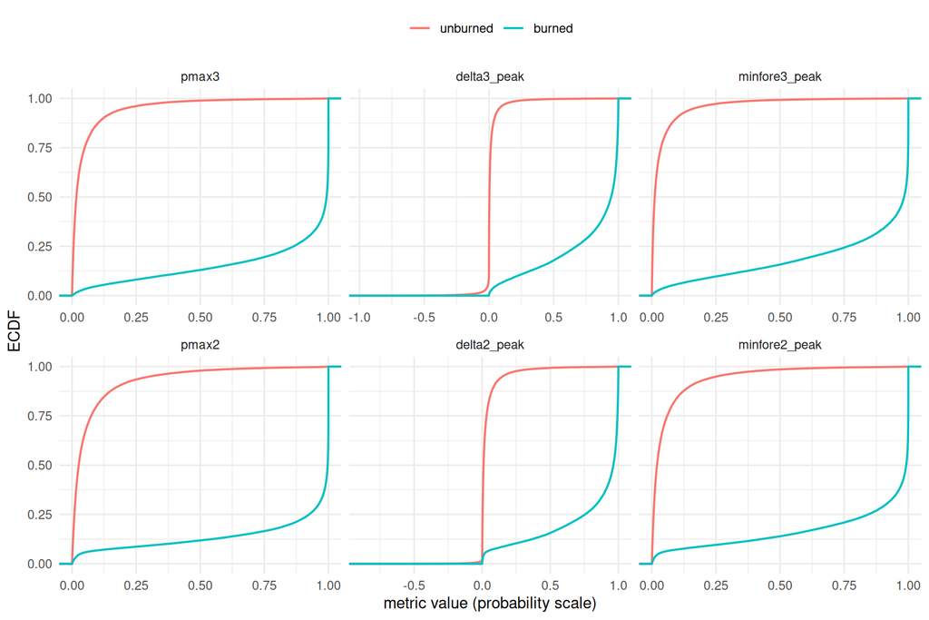

```r
long <- melt(d, id.vars = "label",
             measure.vars = c(seed_metrics, cand_metrics),
             variable.name = "metric", value.name = "value", na.rm = TRUE)

ggplot(long, aes(value, colour = factor(label, labels = lab))) +
  stat_ecdf(linewidth = 0.7) +
  facet_wrap(~ metric, scales = "free_x") +
  labs(colour = NULL, x = "metric value (probability scale)", y = "ECDF") +
  theme(legend.position = "top")
```

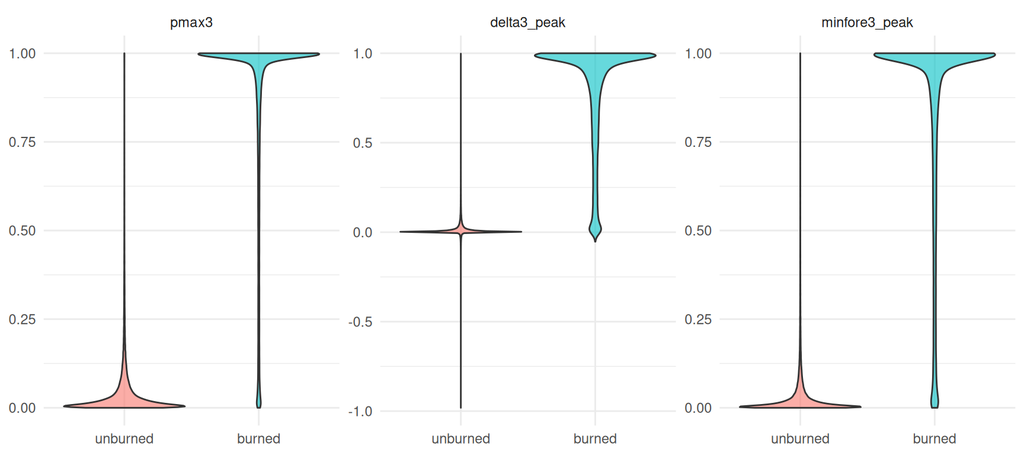

```r
ggplot(long[metric %in% seed_metrics],
       aes(factor(label, labels = lab), value, fill = factor(label, labels = lab))) +
  geom_violin(alpha = 0.6, scale = "width") +
  facet_wrap(~ metric, scales = "free_y") +
  labs(x = NULL, y = NULL, fill = NULL) +
  theme(legend.position = "none")
```

# 4 Commission / omission vs threshold

For each metric, sweep the threshold: **commission** = fraction of *kept* points that are unburned (precision failure); **omission** = fraction of *burned* points *below* the cut (recall failure). Read the seed cut off commission, the candidate cut off omission.

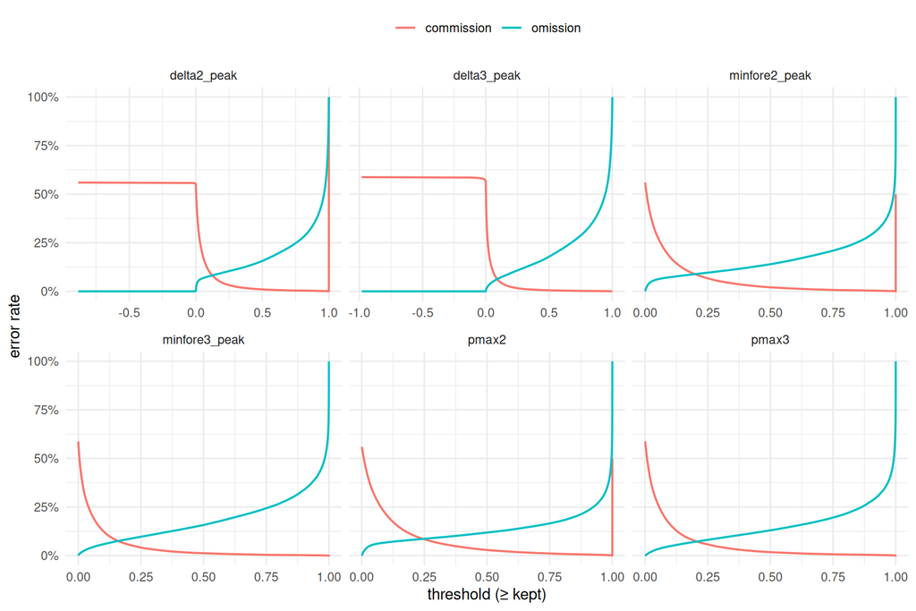

```r
co_curve <- function(dt, metric, n = 200) {
  v <- dt[[metric]]; y <- dt$label
  ok <- !is.na(v); v <- v[ok]; y <- y[ok]
  thr <- unique(quantile(v, probs = seq(0, 1, length.out = n), na.rm = TRUE))
  rbindlist(lapply(thr, function(t) data.table(
    metric = metric, threshold = t,
    commission = if (sum(v >= t)) mean(y[v >= t] == 0L) else NA_real_,
    omission   = mean(v[y == 1L] < t))))
}
curves <- rbindlist(lapply(c(seed_metrics, cand_metrics), co_curve, dt = d))

ggplot(melt(curves, id.vars = c("metric", "threshold"),
            variable.name = "error", value.name = "rate"),
       aes(threshold, rate, colour = error)) +
  geom_line(linewidth = 0.7) +
  facet_wrap(~ metric, scales = "free_x") +
  scale_y_continuous(labels = percent) +
  labs(x = "threshold (≥ kept)", y = "error rate", colour = NULL) +
  theme(legend.position = "top")
```

```r
# TODO: mark chosen seed (low-commission) & candidate (low-omission) cuts, then
# transcribe to config/snic_seed_candidate_thresholds.csv.
```

# 5 Joint separation & a shallow tree

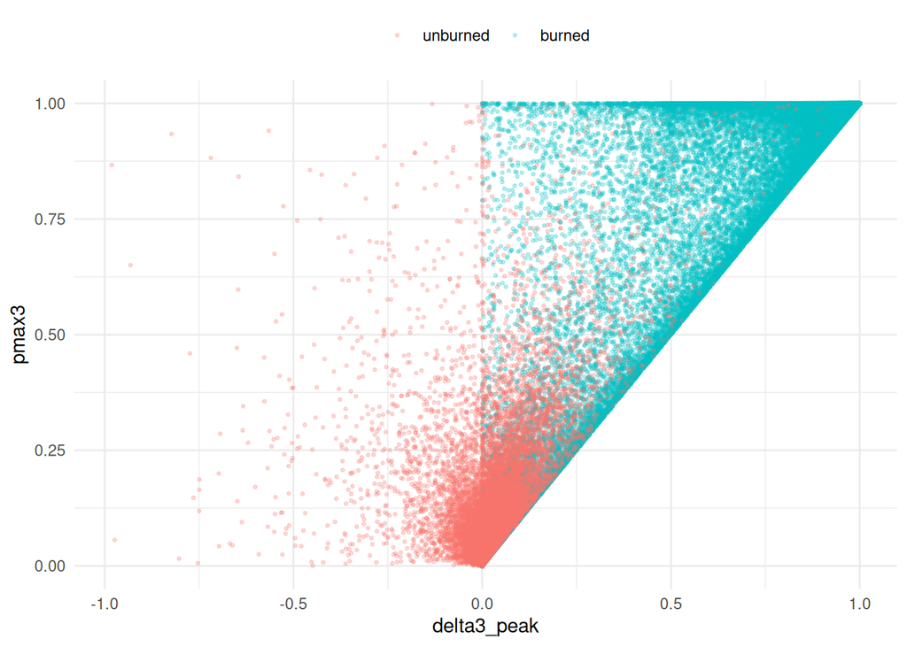

```r
ggplot(d, aes(delta3_peak, pmax3, colour = factor(label, labels = lab))) +
  geom_point(alpha = 0.25, size = 0.6) +
  labs(colour = NULL, x = "delta3_peak", y = "pmax3") +
  theme(legend.position = "top")
```

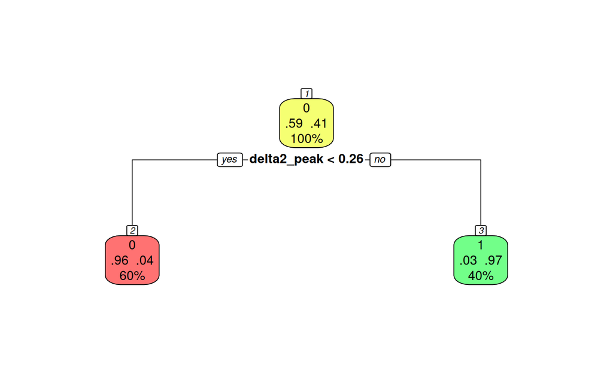

```r
# Shallow tree as a GUIDE (not a deployable model): which splits does the data
# suggest, and does it plateau short of clean separation?
dt <- d[!is.na(delta3_peak)]
fit <- rpart(label ~ pmax3 + delta3_peak + minfore3_peak + pmax2 +
               delta2_peak + minfore2_peak + n,
             data = dt, method = "class",
             control = rpart.control(maxdepth = 3, cp = 0.005))
rpart.plot(fit, extra = 104, box.palette = "RdYlGn", nn = TRUE)
```

```r
cat(sprintf("resubstitution accuracy (depth ≤3): %.3f\n",
            mean(predict(fit, type = "class") == dt$label)))
```

```
resubstitution accuracy (depth ≤3): 0.964
```

```r
# Near-ceiling => empirical tree suffices, no second model. Clear plateau => model.
```

# 6 Pixel-wise K: the n-breakpoint sweep

The candseed surface can be defined by `deltaK_peak` alone, but with **K chosen per pixel**: since `deltaK_peak = minforeK − maxbackK` already bakes K-consecutive persistence into the metric, *choosing K = choosing how much persistence to demand*. Fast-recovery vegetation and sparse series (`n` low) can’t sustain K=3, so they want K=2. We locate the switch with a **sweep over the n-breakpoint** `b`: obs with `n ≥ b` use K=3 (`delta3`), obs with `n < b` use K=2 (`delta2`). Sweeping `b` from above `max(n)` (all K=2) down to `min(n)` (all K=3) traces the recall cost of pushing toward K=3.

**Two ways to score each breakpoint** (they differ, and the difference matters):

- **mixed-column AUC** — pool every pixel’s assigned-`deltaK` into one score, one AUC. But `delta3 ≤ delta2` *pointwise*, so this ranks delta2 pixels against delta3 pixels across a scale gap, which can manufacture a monotone “K2 wins”.
- **weighted per-subgroup AUC** — `AUC(delta2)` on the `n<b` group and `AUC(delta3)` on the `n≥b` group, averaged by group N. Scale-free (each AUC is within one metric), matches setting a **threshold per metric**, and its interior can rise *above* both ends — where a genuine crossover would appear.

Missing K=3 (`delta3 = NA`: <3 post-fire obs) is scored **worst-ranked**: routing a burned pixel to a K it can’t populate is a missed detection, not a pixel to drop.

```r
setDT(d)
d[, n := as.integer(round(n))]
d[, d2 := fifelse(is.na(delta2_peak), -2, delta2_peak)]   # NA-as-worst sentinel
d[, d3 := fifelse(is.na(delta3_peak), -2, delta3_peak)]

auc <- function(s, y){
  ok <- !is.na(s); s <- s[ok]; y <- y[ok]
  n1 <- sum(y == 1L); n0 <- sum(y == 0L)
  if (n1 == 0L || n0 == 0L) return(NA_real_)
  r <- rank(s)
  (sum(r[y == 1L]) - n1 * (n1 + 1) / 2) / (as.double(n1) * n0)
}

sweep_one <- function(sub){
  ns <- sort(unique(sub$n)); breaks <- c(ns, max(ns) + 1L)
  y <- sub$label; d2 <- sub$d2; d3 <- sub$d3; nn <- sub$n
  rbindlist(lapply(breaks, function(b){
    high <- nn >= b; low <- !high
    a_k2 <- if (any(low))  auc(d2[low],  y[low])  else NA_real_
    a_k3 <- if (any(high)) auc(d3[high], y[high]) else NA_real_
    Nl <- sum(low); Nh <- sum(high)
    parts <- c(a_k2, a_k3); w <- c(Nl, Nh); keep <- !is.na(parts)
    data.table(
      n_break      = b,
      auc_mixed    = auc(fifelse(high, d3, d2), y),
      auc_weighted = if (any(keep)) sum(parts[keep] * w[keep]) / sum(w[keep]) else NA_real_,
      auc_k2 = a_k2, auc_k3 = a_k3, N_at = sum(nn == b))
  }))
}

veg_ord <- d[, .N, by = veg_fire_name][order(-N)]
d[, veg_fac := factor(veg_fire_name, levels = veg_ord$veg_fire_name)]
sw <- d[, sweep_one(.SD), by = veg_fac]
```

## 6.1 mixed-column vs weighted per-subgroup

Grey = mixed-column (one pooled AUC); red = weighted per-subgroup (your method). Right edge = all K=2, left edge = all K=3. Fixed axes for comparison.

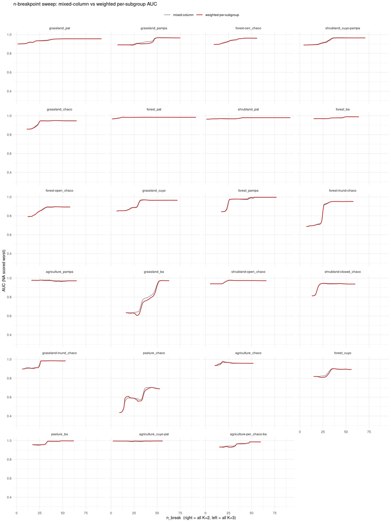

```r
m <- melt(sw, id.vars = c("veg_fac", "n_break"),
          measure.vars = c("auc_mixed", "auc_weighted"),
          variable.name = "method", value.name = "auc")
m[, method := factor(method, c("auc_mixed", "auc_weighted"),
                     c("mixed-column", "weighted per-subgroup"))]
ggplot(m, aes(n_break, auc, colour = method)) +
  geom_line(linewidth = 0.6) +
  facet_wrap(~ veg_fac, ncol = 4) +
  coord_cartesian(ylim = c(0.3, 1)) +
  scale_colour_manual(values = c("mixed-column" = "grey60",
                                 "weighted per-subgroup" = "firebrick"), name = NULL) +
  labs(x = "n_break  (right = all K=2, left = all K=3)",
       y = "AUC (NA scored worst)",
       title = "n-breakpoint sweep: mixed-column vs weighted per-subgroup AUC") +
  theme_minimal(base_size = 9) + theme(legend.position = "top")
```

## 6.2 Component curves: AUC(delta2) low-group vs AUC(delta3) high-group

The crossover, read directly: at each `b`, how well `delta2` separates the sparse (`n<b`) group vs how well `delta3` separates the dense (`n≥b`) group. Where the K=3 line sits *above* the K=2 line, K=3 earns the switch.

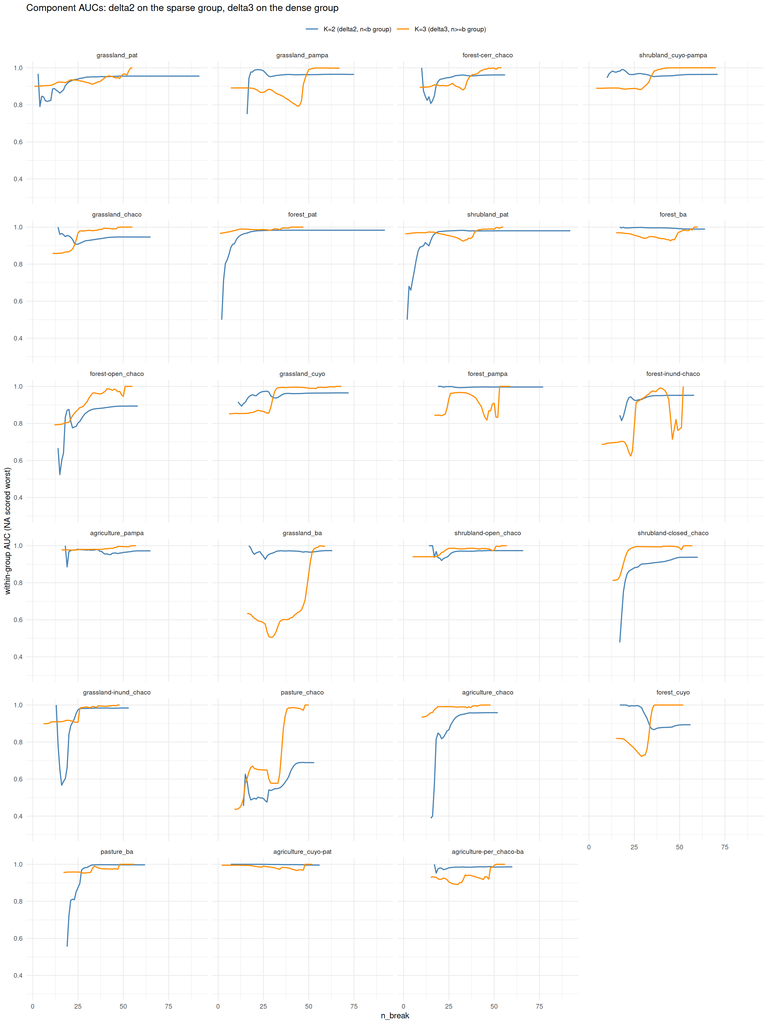

```r
cc <- melt(sw, id.vars = c("veg_fac", "n_break"),
           measure.vars = c("auc_k2", "auc_k3"),
           variable.name = "metric", value.name = "auc")
cc[, metric := factor(metric, c("auc_k2", "auc_k3"),
                      c("K=2 (delta2, n<b group)", "K=3 (delta3, n>=b group)"))]
ggplot(cc, aes(n_break, auc, colour = metric)) +
  geom_line(linewidth = 0.6) +
  facet_wrap(~ veg_fac, ncol = 4) +
  coord_cartesian(ylim = c(0.3, 1)) +
  scale_colour_manual(values = c("K=2 (delta2, n<b group)" = "steelblue",
                                 "K=3 (delta3, n>=b group)" = "darkorange"), name = NULL) +
  labs(x = "n_break", y = "within-group AUC (NA scored worst)",
       title = "Component AUCs: delta2 on the sparse group, delta3 on the dense group") +
  theme_minimal(base_size = 9) + theme(legend.position = "top")
```

## 6.3 How much of "K=2 wins" is the NA penalty?

Same weighted sweep, NA-as-worst vs `na.omit`, by recovery group (woody/steppe = slow; grassland/pasture/agriculture = fast). If the two collapse, the NA penalty is the whole story; if K=3 still trails under `na.omit`, its recall shortfall is genuine.

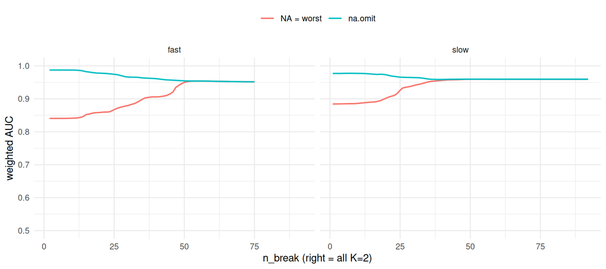

```r
d[, recov := fifelse(grepl("forest|shrubland", veg_fire_name) |
                     veg_fire_name == "grassland_pat", "slow", "fast")]
sweep_na <- function(sub, sentinel){
  v2 <- if (sentinel) sub$d2 else sub$delta2_peak
  v3 <- if (sentinel) sub$d3 else sub$delta3_peak
  ns <- sort(unique(sub$n)); breaks <- c(ns, max(ns) + 1L); y <- sub$label; nn <- sub$n
  rbindlist(lapply(breaks, function(b){
    high <- nn >= b; low <- !high
    a2 <- if (any(low)) auc(v2[low], y[low]) else NA
    a3 <- if (any(high)) auc(v3[high], y[high]) else NA
    p <- c(a2, a3); w <- c(sum(low), sum(high)); k <- !is.na(p)
    data.table(n_break = b, auc = if (any(k)) sum(p[k] * w[k]) / sum(w[k]) else NA)
  }))
}
na_cmp <- rbindlist(list(
  d[, sweep_na(.SD, TRUE),  by = recov][, na := "NA = worst"],
  d[, sweep_na(.SD, FALSE), by = recov][, na := "na.omit"]))
ggplot(na_cmp, aes(n_break, auc, colour = na)) +
  geom_line(linewidth = 0.7) + facet_wrap(~ recov) +
  coord_cartesian(ylim = c(0.5, 1)) +
  labs(x = "n_break (right = all K=2)", y = "weighted AUC", colour = NULL) +
  theme_minimal() + theme(legend.position = "top")
```

## 6.4 Summary: does the weighted curve ever beat both ends?

`interior_gain > 0` means the pixel-wise mix (weighted AUC) peaks **above** both all-K=2 and all-K=3 — a genuine crossover justifying a per-veg breakpoint. `≈ 0` means one endpoint is as good as any mix.

```r
summ <- sw[, {
  k2 <- auc_weighted[n_break == max(n_break)]
  k3 <- auc_weighted[n_break == min(n_break)]
  bi <- which.max(auc_weighted)
  .(AUC_allK2 = round(k2, 3), AUC_allK3 = round(k3, 3),
    AUC_wbest = round(auc_weighted[bi], 3), nbreak_best = n_break[bi],
    interior_gain = round(auc_weighted[bi] - max(k2, k3, na.rm = TRUE), 3))
}, by = veg_fac]
merge(veg_ord[, .(veg_fac = factor(veg_fire_name, levels = veg_ord$veg_fire_name), N)],
      summ, by = "veg_fac")[order(-interior_gain)] |>
  kable(caption = "Per-veg n-breakpoint sweep (weighted AUC). interior_gain>0 = real crossover.")
```

Per-veg n-breakpoint sweep (weighted AUC). interior_gain>0 = real crossover.

| veg_fac | N | AUC_allK2 | AUC_allK3 | AUC_wbest | nbreak_best | interior_gain |
| --- | --- | --- | --- | --- | --- | --- |
| agriculture_chaco | 1645 | 0.959 | 0.934 | 0.978 | 19 | 0.020 |
| pasture_chaco | 2120 | 0.689 | 0.436 | 0.702 | 44 | 0.013 |
| forest_cuyo | 1397 | 0.893 | 0.819 | 0.901 | 38 | 0.008 |
| shrubland-closed_chaco | 2920 | 0.938 | 0.813 | 0.944 | 25 | 0.007 |
| shrubland-open_chaco | 3051 | 0.974 | 0.941 | 0.978 | 27 | 0.005 |
| grassland_cuyo | 3691 | 0.965 | 0.852 | 0.969 | 36 | 0.004 |
| grassland_pampa | 23211 | 0.964 | 0.891 | 0.967 | 53 | 0.003 |
| grassland_chaco | 5667 | 0.946 | 0.858 | 0.949 | 42 | 0.003 |
| forest-open_chaco | 4091 | 0.894 | 0.793 | 0.896 | 45 | 0.003 |
| agriculture_pampa | 3427 | 0.972 | 0.977 | 0.980 | 26 | 0.002 |
| grassland-inund_chaco | 2266 | 0.984 | 0.899 | 0.986 | 36 | 0.002 |
| forest-cerr_chaco | 21690 | 0.962 | 0.895 | 0.962 | 45 | 0.001 |
| forest_pat | 5419 | 0.983 | 0.966 | 0.984 | 13 | 0.001 |
| grassland_ba | 3134 | 0.974 | 0.634 | 0.975 | 56 | 0.001 |
| pasture_ba | 613 | 0.997 | 0.956 | 0.998 | 48 | 0.001 |
| agriculture-per_chaco-ba | 354 | 0.986 | 0.929 | 0.987 | 48 | 0.001 |
| grassland_pat | 30926 | 0.955 | 0.900 | 0.955 | 54 | 0.000 |
| shrubland_cuyo-pampa | 11801 | 0.964 | 0.889 | 0.965 | 48 | 0.000 |
| shrubland_pat | 5385 | 0.980 | 0.964 | 0.980 | 47 | 0.000 |
| forest_ba | 4930 | 0.989 | 0.970 | 0.990 | 55 | 0.000 |
| forest_pampa | 3674 | 0.997 | 0.844 | 0.997 | 53 | 0.000 |
| forest-inund-chaco | 3655 | 0.952 | 0.687 | 0.952 | 39 | 0.000 |
| agriculture_cuyo-pat | 504 | 0.996 | 0.995 | 0.996 | 48 | 0.000 |

# 7 Initial candseed values: 5 per veg

Per veg we need **five** starting numbers: `n_break` (K=2 below, K=3 at/above) and a **candidate** + **seed** threshold for **each** of delta2 and delta3. Rules, both sides using **base-rate-invariant** (within-class) error rates so they transfer from this ~44%-burned set to ~1%-burned deployment:

- **candidate = highest threshold with omission ≤ 5 %** (recall ≥ 95 %; omission is within the burned class).
- **seed = lowest threshold with FPR ≤ 2 %** (≤ 2 % of *unburned* kept; specificity ≥ 98 %). This is the transfer-safe replacement for a raw commission bar, which is base-rate-dependent and thus not portable to deployment.

Thresholds are calibrated on the **full per-veg data** (all `n`), so they are **independent of `n_break`** — the breakpoint can be re-tuned on the maps while the same delta cuts hold (valid here because low-`n` is only ~0.5 % of the data, so delta3’s NA rate is recovery-driven, not sparsity-driven). `n_break` is the knee of the weighted sweep (§sec-nbreak): the lowest breakpoint within 0.01 AUC of all-K=2.

```r
OM_BAR <- 0.05; FPR_BAR <- 0.02
grid <- seq(0, 1, by = 0.004)

# n_break: knee of weighted sweep (contiguous from all-K2, tol 0.01)
nbrk <- sw[order(veg_fac, -n_break), {
  k2 <- auc_weighted[1]; knee <- n_break[1]
  for (i in seq_along(n_break))
    if (!is.na(auc_weighted[i]) && auc_weighted[i] >= k2 - 0.01) knee <- n_break[i] else break
  .(n_break = knee)
}, by = veg_fac]

pick <- function(vals, y){                       # vals = sentinel (-2) delta
  om <- vapply(grid, function(t) mean(vals[y == 1L] <  t), 0)   # omission (increasing in t)
  fp <- vapply(grid, function(t) mean(vals[y == 0L] >= t), 0)   # FPR      (decreasing in t)
  t_om  <- { ok <- which(om <= OM_BAR);  if (length(ok)) grid[max(ok)] else NA_real_ }  # recall bar
  t_fpr <- { ok <- which(fp <= FPR_BAR); if (length(ok)) grid[min(ok)] else NA_real_ }  # precision bar
  # order loose<strict: candidate = lower cut, seed = higher cut (seed subset of candidate).
  # separable veg can meet both bars over a wide band, so t_om may exceed t_fpr — min/max fixes it.
  if (!is.na(t_om) && !is.na(t_fpr))
    list(cand = min(t_om, t_fpr), seed = max(t_om, t_fpr))
  else list(cand = t_om, seed = t_fpr)           # only one bar met: keep its role
}
picks <- d[, {
  p2 <- pick(d2, label); p3 <- pick(d3, label)
  .(K2_cand = p2$cand, K2_seed = p2$seed,
    K3_cand = p3$cand, K3_seed = p3$seed)
}, by = veg_fac]

vegN <- d[, .N, by = veg_fac]
five <- Reduce(function(a, b) merge(a, b, by = "veg_fac"), list(vegN, nbrk, picks))
setorder(five, -N)
five[, .(veg_fac, N, n_break,
         K2_cand = round(K2_cand, 3), K2_seed = round(K2_seed, 3),
         K3_cand = round(K3_cand, 3), K3_seed = round(K3_seed, 3),
         note = fifelse(is.na(K3_cand), "K3 omission floor >5% -> K2-only veg", ""))] |>
  kable(caption = "Initial 5-value candseed table per veg (delta thresholds, sentinel scale).")
```

Initial 5-value candseed table per veg (delta thresholds, sentinel scale).

| veg_fac | N | n_break | K2_cand | K2_seed | K3_cand | K3_seed | note |
| --- | --- | --- | --- | --- | --- | --- | --- |
| grassland_pat | 30926 | 36 | 0.040 | 0.292 | NA | 0.184 | K3 omission floor >5% -> K2-only veg |
| grassland_pampa | 23211 | 48 | 0.032 | 0.352 | NA | 0.196 | K3 omission floor >5% -> K2-only veg |
| forest-cerr_chaco | 21690 | 35 | 0.012 | 0.120 | NA | 0.060 | K3 omission floor >5% -> K2-only veg |
| shrubland_cuyo-pampa | 11801 | 35 | 0.024 | 0.152 | NA | 0.076 | K3 omission floor >5% -> K2-only veg |
| grassland_chaco | 5667 | 25 | 0.000 | 0.124 | NA | 0.056 | K3 omission floor >5% -> K2-only veg |
| forest_pat | 5419 | 7 | 0.188 | 0.256 | 0.052 | 0.180 |  |
| shrubland_pat | 5385 | 34 | 0.260 | 0.416 | 0.068 | 0.244 |  |
| forest_ba | 4930 | 46 | 0.356 | 0.508 | 0.176 | 0.428 |  |
| forest-open_chaco | 4091 | 31 | 0.000 | 0.068 | NA | 0.032 | K3 omission floor >5% -> K2-only veg |
| grassland_cuyo | 3691 | 32 | 0.036 | 0.232 | NA | 0.128 | K3 omission floor >5% -> K2-only veg |
| forest_pampa | 3674 | 49 | 0.032 | 0.940 | NA | 0.016 | K3 omission floor >5% -> K2-only veg |
| forest-inund-chaco | 3655 | 32 | 0.028 | 0.568 | NA | 0.448 | K3 omission floor >5% -> K2-only veg |
| agriculture_pampa | 3427 | 16 | 0.040 | 0.276 | 0.012 | 0.128 |  |
| grassland_ba | 3134 | 52 | 0.048 | 0.380 | NA | 0.172 | K3 omission floor >5% -> K2-only veg |
| shrubland-open_chaco | 3051 | 23 | 0.068 | 0.148 | 0.000 | 0.060 |  |
| shrubland-closed_chaco | 2920 | 21 | 0.008 | 0.216 | NA | 0.092 | K3 omission floor >5% -> K2-only veg |
| grassland-inund_chaco | 2266 | 26 | 0.360 | 0.368 | NA | 0.260 | K3 omission floor >5% -> K2-only veg |
| pasture_chaco | 2120 | 39 | 0.000 | 0.276 | NA | 0.200 | K3 omission floor >5% -> K2-only veg |
| agriculture_chaco | 1645 | 14 | 0.028 | 0.540 | NA | 0.360 | K3 omission floor >5% -> K2-only veg |
| forest_cuyo | 1397 | 34 | 0.004 | 0.188 | NA | 0.096 | K3 omission floor >5% -> K2-only veg |
| pasture_ba | 613 | 34 | 0.204 | 0.608 | 0.016 | 0.068 |  |
| agriculture_cuyo-pat | 504 | 2 | 0.224 | 0.508 | 0.132 | 0.372 |  |
| agriculture-per_chaco-ba | 354 | 48 | 0.384 | 0.624 | 0.000 | 0.344 |  |

## 7.1 Omission & FPR curves per veg — pick / override by eye

Two columns (delta2, delta3), one row per veg, free scales. Orange = omission (burned missed), purple = FPR (unburned kept). Dashed green = chosen **candidate** (omission side), dashed red = chosen **seed** (FPR side). Where the delta3 omission curve never dips under 5 % (floor above the line), K=3 can’t serve that veg — it’s K=2-only, consistent with a high `n_break`.

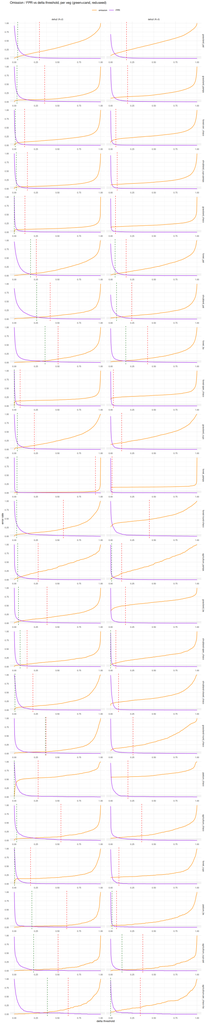

```r
cv <- function(vals, y) data.table(t = grid,
  omission = vapply(grid, function(t) mean(vals[y == 1L] <  t), 0),
  FPR      = vapply(grid, function(t) mean(vals[y == 0L] >= t), 0))
curve_dt <- d[, rbind(cbind(K = "delta2 (K=2)", cv(d2, label)),
                      cbind(K = "delta3 (K=3)", cv(d3, label))), by = veg_fac]
cl <- melt(curve_dt, id.vars = c("veg_fac", "K", "t"),
           variable.name = "error", value.name = "rate")

vl <- rbind(
  picks[, .(veg_fac, K = "delta2 (K=2)", cand = K2_cand, seed = K2_seed)],
  picks[, .(veg_fac, K = "delta3 (K=3)", cand = K3_cand, seed = K3_seed)])

ggplot(cl, aes(t, rate, colour = error)) +
  geom_hline(yintercept = c(OM_BAR, FPR_BAR), colour = "grey80", linewidth = 0.3) +
  geom_line(linewidth = 0.5) +
  geom_vline(data = vl, aes(xintercept = cand), colour = "darkgreen", linetype = 2, linewidth = 0.4) +
  geom_vline(data = vl, aes(xintercept = seed), colour = "red", linetype = 2, linewidth = 0.4) +
  facet_grid(veg_fac ~ K, scales = "free", axes = "all_x", axis.labels = "all_x") +
  scale_colour_manual(values = c(omission = "darkorange", FPR = "purple"), name = NULL) +
  labs(x = "delta threshold", y = "error rate",
       title = "Omission / FPR vs delta threshold, per veg (green=cand, red=seed)") +
  theme_minimal(base_size = 8) + theme(legend.position = "top")
```

# 8 Stratification — does one threshold set hold?

Separability drifts by vegetation and observation density (grassland recovers fast, forest slow; sparse series overlap more). If the cut moves a lot across strata, seeds/candidates may need to be veg/region-stratified.

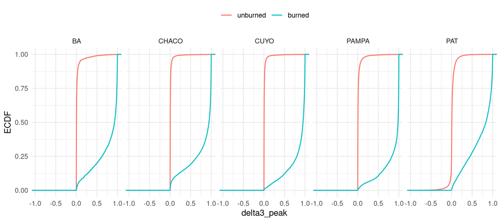

```r
ggplot(d, aes(delta3_peak, colour = factor(label, labels = lab))) +
  stat_ecdf(linewidth = 0.6) +
  facet_wrap(~ region, nrow = 1) +
  labs(colour = NULL, x = "delta3_peak", y = "ECDF") +
  theme(legend.position = "top")
```

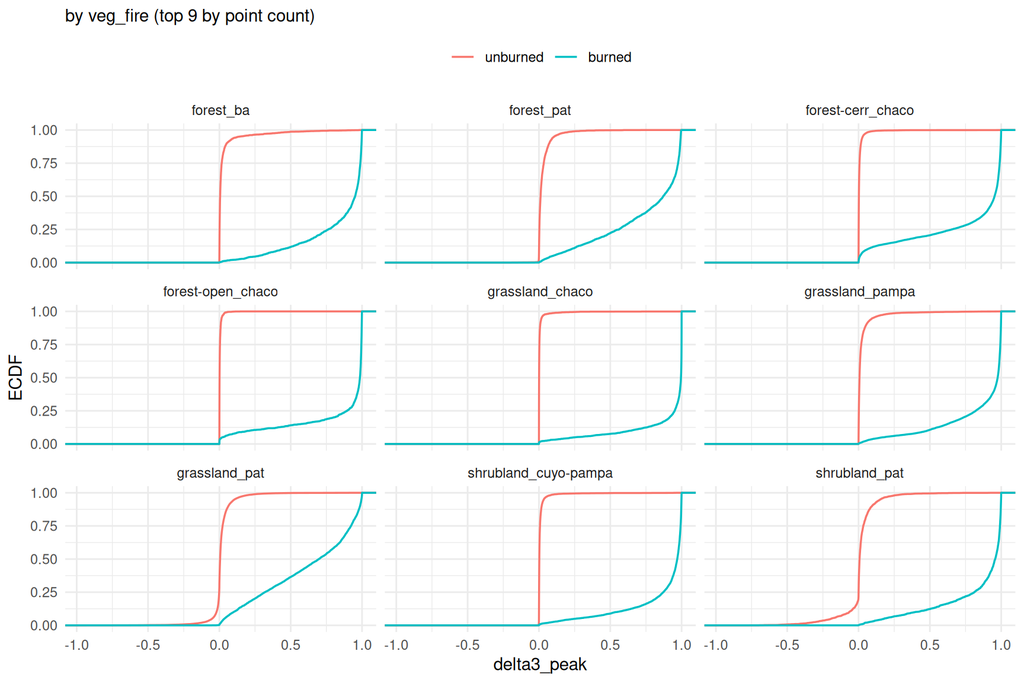

```r
top_veg <- d[, .N, by = veg_fire_name][order(-N)][1:9, veg_fire_name]
ggplot(d[veg_fire_name %in% top_veg],
       aes(delta3_peak, colour = factor(label, labels = lab))) +
  stat_ecdf(linewidth = 0.6) +
  facet_wrap(~ veg_fire_name) +
  labs(colour = NULL, x = "delta3_peak", y = "ECDF",
       subtitle = "by veg_fire (top 9 by point count)") +
  theme(legend.position = "top")
```

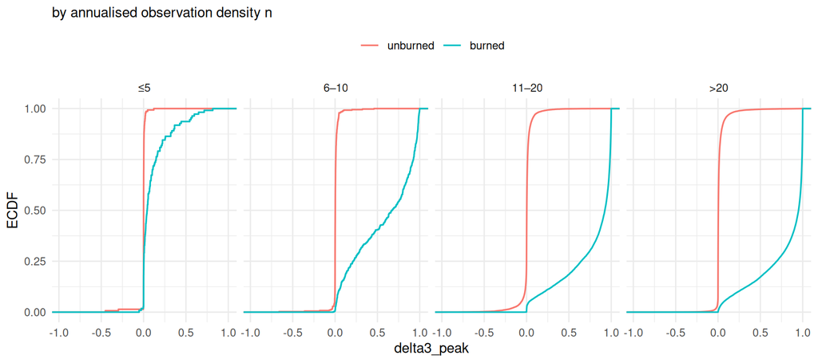

```r
d[, n_bin := cut(n, breaks = c(-Inf, 5, 10, 20, Inf),
                 labels = c("≤5", "6–10", "11–20", ">20"))]
ggplot(d[!is.na(n_bin)], aes(delta3_peak, colour = factor(label, labels = lab))) +
  stat_ecdf(linewidth = 0.6) +
  facet_wrap(~ n_bin, nrow = 1) +
  labs(colour = NULL, x = "delta3_peak", y = "ECDF",
       subtitle = "by annualised observation density n") +
  theme(legend.position = "top")
```

# 9 Transfer to production & proposed thresholds

These metrics are **period-based**; production applies the cuts to the **year-based** `bpts`. Confirm the single-fire hard-check (`scripts/test-bp_ts_metrics_local.R`) passes on the magnitude metrics before committing thresholds. Then transcribe the seed (precision-side) and candidate (recall-side) cuts into `config/snic_seed_candidate_thresholds.csv` (hand-editable; the SNIC step reads them) and record here the values chosen, the reasoning, and whether a single global set held or stratification was needed.

```r
# TODO: fill in from the curves above, e.g.
# fread("../config/snic_seed_candidate_thresholds.csv") |> kable()
```